# Impact of reference bundle on scRNA-Seq gene quantification

About this notebook This notebook is part of analysis of evaluate the impact of different reference bundle on scRNA-Seq quantification. # Annotation First we need to use package `rtracklayer` to load several gene annotation gtf files. * [Ensembl](https://www.ensembl.org/info/data/ftp/index.html) * [refseq](https://www.ncbi.nlm.nih.gov/projects/genome/guide/human/index.shtml) * [gencodeV27](https://www.gencodegenes.org/releases/current.html)

```r
library('ggplot2')
library('rtracklayer')
system.time(gtf_gencode_comp <- readGFF("~/Documents/HCA/reference/refs/gencode.v27.chr_patch_hapl_scaff.annotation.gtf", version=2L, tags = c("gene_name","gene_id", "transcript_id","gene_type")))
```

```
##    user  system elapsed
##  17.740   1.157  19.465
```

```r
system.time(gtf_gencode_basic <- readGFF("~/Documents/HCA/reference/refs/gencode.v27.chr_patch_hapl_scaff.basic.annotation.gtf", version=2L, tags = c("gene_name","gene_id", "transcript_id","gene_type")))
```

```
##    user  system elapsed
##   9.188   0.654   9.981
```

```r
system.time(gtf_ensembl <- readGFF("~/Documents/HCA/reference/refs/Homo_sapiens.GRCh38.90.gtf", version=2L,tags = c("gene_name","gene_id", "transcript_id","gene_biotype")))
```

```
##    user  system elapsed
##  14.585   0.907  15.667
```

```r
system.time(gtf_refseq <- readGFF("~/Documents/HCA/reference/refs/ncbi-genomes-2017-10-05/GCF_000001405.37_GRCh38.p11_genomic.gff.gz", tags = c("ID", "Name","gbkey","gene","gene_biotype","Parent")))
```

```
##    user  system elapsed
##  22.809   0.651  23.497
```

some header of gtf files

```r
tags<-c('GeneID','Chr','Start','End','Strand','Length','Counts')
head(gtf_ensembl)
```

```
##   seqid source       type start   end score strand phase gene_name
## 1     1 havana       gene 11869 14409    NA      +    NA   DDX11L1
## 2     1 havana transcript 11869 14409    NA      +    NA   DDX11L1
## 3     1 havana       exon 11869 12227    NA      +    NA   DDX11L1
## 4     1 havana       exon 12613 12721    NA      +    NA   DDX11L1
## 5     1 havana       exon 13221 14409    NA      +    NA   DDX11L1
## 6     1 havana transcript 12010 13670    NA      +    NA   DDX11L1
##           gene_id   transcript_id                       gene_biotype
## 1 ENSG00000223972            <NA> transcribed_unprocessed_pseudogene
## 2 ENSG00000223972 ENST00000456328 transcribed_unprocessed_pseudogene
## 3 ENSG00000223972 ENST00000456328 transcribed_unprocessed_pseudogene
## 4 ENSG00000223972 ENST00000456328 transcribed_unprocessed_pseudogene
## 5 ENSG00000223972 ENST00000456328 transcribed_unprocessed_pseudogene
## 6 ENSG00000223972 ENST00000450305 transcribed_unprocessed_pseudogene
```

# Impact on gene quantification overview

a set of gene quantification results is shown as below. First the gene counts from `ensembl` bundle. The `SRR1294900_25_GRCh38_Ensembl.gene.unq.counts.txt` is generated from `featureCounts` with `unique` option

## load Ensembl bundle results

```r
ensembl.counts<-read.delim('/Users/jishuxu/Documents/HCA/reference/counts/SRR1294900_25_GRCh38_Ensembl.gene.unq.counts.txt',sep='\t',header=T,skip=1)
colnames(ensembl.counts)<-tags
mlist<-match(ensembl.counts$GeneID,gtf_ensembl$gene_id)
geneName<-gtf_ensembl$gene_name[mlist]
btype<-gtf_ensembl$gene_biotype[mlist]
c1<-data.frame("geneName"=geneName,'Ensembl.Counts'=log(ensembl.counts$Counts+1,base=2),'Ensembl.type'=gtf_ensembl$gene_biotype[mlist])
head(c1)
```

```
##      geneName Ensembl.Counts                       Ensembl.type
## 1     DDX11L1              0 transcribed_unprocessed_pseudogene
## 2      WASH7P              0             unprocessed_pseudogene
## 3   MIR6859-1              0                              miRNA
## 4 MIR1302-2HG              0                            lincRNA
## 5   MIR1302-2              0                              miRNA
## 6     FAM138A              0                            lincRNA
```

If we define `detected genes` as genes with coverage >0 and `good coverage genes` as genes with coverage >5. Then we can plot the top 10 biotype categories.

```r
gene.detects<-list()
t1<-sort(table(c1[c1$Ensembl.Counts>0,3]),decreasing=T)
t2<-sort(table(c1[c1$Ensembl.Counts>5,3]),decreasing=T)
gene.detects[['ensembl']]<-cbind('detected.genes'=t1[1:10],'good.genes'=t2[1:10])
```

## load `RefSeq` bundle results

Then the gene counts from `RefSeq`.

```r
refseq.counts<-read.delim('/Users/jishuxu/Documents/HCA/reference/counts/SRR1294900_25_GRCh38_RefSeq.gene.unq.counts.txt',sep='\t',header=T,skip=1)
colnames(refseq.counts)<-tags
mlist<-match(refseq.counts$GeneID,gtf_refseq$ID)
geneName<-gtf_refseq$Name[mlist]
c2<-data.frame("geneName"=geneName,"RefSeq.Counts"=log(refseq.counts$Counts+1,base=2),'RefSeq.type'=gtf_refseq$gene_biotype[mlist])
head(c2)
```

```
##       geneName RefSeq.Counts            RefSeq.type
## 1      DDX11L1             0 transcribed_pseudogene
## 2       WASH7P             0 transcribed_pseudogene
## 3    MIR6859-1             0                  miRNA
## 4 LOC107985730             0                 lncRNA
## 5    MIR1302-2             0                  miRNA
## 6      FAM138A             0                 lncRNA
```

summary `detected genes` and `good genes` based on biotype.

```r
t1<-sort(table(c2[c2$RefSeq.Counts>0,3]),decreasing=T)
t2<-sort(table(c2[c2$RefSeq.Counts>5,3]),decreasing=T)
gene.detects[['refseq']]<-cbind('detected.genes'=t1[1:10],'good.genes'=t2[1:10])
```

## load `gencode` bundle results

- For GencodeV27, there are two reference bundle `GencodeV27 Comprehansive` and `GencodeV27 Basic`. Repeat the similar analysis.

```r
gencode.counts.comp<-read.delim('/Users/jishuxu/Documents/HCA/reference/counts/SRR1294900_25_GRCh38_GencodeV27.gene.unq.counts.txt',sep='\t',header=T,skip=1)
colnames(gencode.counts.comp)<-tags
mlist<-match(gencode.counts.comp$GeneID,gtf_gencode_comp$gene_id)
geneName<-gtf_gencode_comp$gene_name[mlist]
c3<-data.frame("geneName"=geneName,"GencodeComp.Counts"=log(gencode.counts.comp$Counts+1,base=2),'Gencode.type'=gtf_gencode_comp$gene_type[mlist])
dim(c3)
```

```
## [1] 63925     3
```

```r
gencode.counts.basic<-read.delim('/Users/jishuxu/Documents/HCA/reference/counts/SRR1294900_25_GRCh38_GencodeV27_basic.gene.unq.counts.txt',sep='\t',header=T,skip=1)
colnames(gencode.counts.basic)<-tags
mlist<-match(gencode.counts.basic$GeneID,gtf_gencode_basic$gene_id)
geneName<-gtf_gencode_basic$gene_name[mlist]
c4<-data.frame("geneName"=geneName,"GencodeBasic.Counts"=log(gencode.counts.basic$Counts+1,base=2),'Gencode.type'=gtf_gencode_basic$gene_type[mlist])
dim(c4)
```

```
## [1] 63925     3
```

- Summary gene coverage based on biotype. For `Comprehansive GencodeV27`

```r
t1<-sort(table(c3[c3$GencodeComp.Counts>0,3]),decreasing=T)
t2<-sort(table(c3[c3$GencodeComp.Counts >5,3]),decreasing=T)
gene.detects[['GencodeComp']]<-cbind('detected.genes'=t1[1:10],'good.genes'=t2[1:10])
```

- Then `Basic GencodeV27`

```r
t1<-sort(table(c4[c4$GencodeBasic.Counts>0,3]),decreasing=T)
t2<-sort(table(c4[c4$GencodeBasic.Counts >5,3]),decreasing=T)
gene.detects[["GencodeBasic"]]<-cbind('detected.genes'=t1[1:10],'good.genes'=t2[1:10])
```

## summary all 4 reference bundle together.

Now we can summary on `detected genes` by `biotype` cross alll 4 reference bundle.

```r
##top 3 biotype
library(reshape2)
bios<-c('protein_coding','processed_pseudogene','pseudogene','lincRNA','lncRNA')
g.ensembl<-subset(gene.detects$ensembl,rownames(gene.detects$ensembl) %in% bios)
g.refseq<-subset(gene.detects$refseq,rownames(gene.detects$refseq) %in% bios)
g.gencode<-subset(gene.detects$GencodeComp,rownames(gene.detects$GencodeComp) %in% bios)
g.gencodeBasic<-subset(gene.detects$GencodeBasic,rownames(gene.detects$GencodeBasic) %in% bios)
detects<-data.frame('biotype'=rep(c('protein_coding','pseudogene','lncRNA'),4),rbind(g.ensembl,g.refseq,g.gencode,g.gencodeBasic),'bundle'=rep(c('Ensembl','RefSeq','Gencode','GencodeV27'),c(3,3,3,3)))
m.detects<-melt(detects)
```

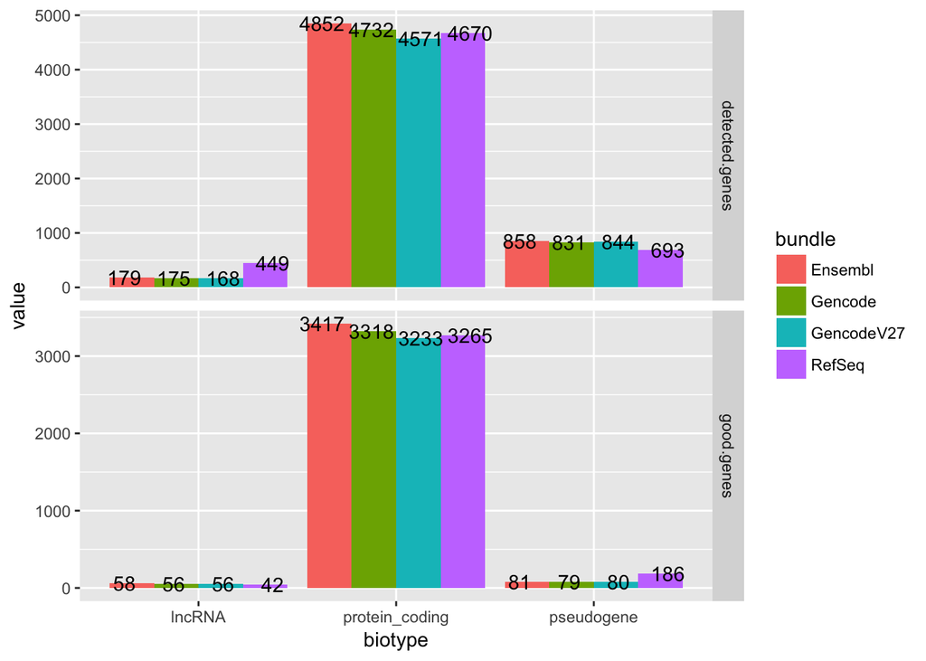

```r
##detected >0X
ggplot(data=m.detects,aes(x=biotype,y=value,fill=bundle))+geom_bar(stat="identity",position=position_dodge())+facet_grid(variable~.,scales="free_y")+geom_text(aes(biotype, value, label = value),position = position_dodge(width = 1))
```

# Evaluate `Dropout`, `overdispersion` events

## `Ensembl` vs `RefSeq`

We compare the gene quantification from `Ensembl` and `RefSeq` reference bundles. We are looking for 3 type of events, `drop-out` if only detectable from one reference bundle but not another, `predictable` if one can be predicted or estimated by another or the observation in one result can fall into prediction interval based on regression model,`overdispersion` if neither `dropout` nor `predictable`, `overdispersion` generally represent some genes have very high expression in one results but very low expression in another. - First merge two quantification by `geneName` or `geneID`.

```r
ensembl.refseq<-merge(c1,c2,by=c('geneName'),all=F,all.x=F,all.y=F)
dim(ensembl.refseq)
```

```
## [1] 32647     5
```

Overlapping genes ID between Ensembl and RefSeq is 32647. - Let’s examine the association between Ensembl and RefSeq quantification. Before the regression analysis, we need to remove `drop-out` genes from both `ensembl` and `refseq`.

```r
subdata<-subset(ensembl.refseq,Ensembl.Counts>0 & RefSeq.Counts >0)
fit<-lm(RefSeq.Counts~Ensembl.Counts, data=subdata)
summary(fit)
```

```
##
## Call:
## lm(formula = RefSeq.Counts ~ Ensembl.Counts, data = subdata)
##
## Residuals:
##     Min      1Q  Median      3Q     Max
## -9.6304 -0.0886  0.0881  0.1788  7.6481
##
## Coefficients:
##                Estimate Std. Error t value Pr(>|t|)
## (Intercept)     0.16485    0.02844   5.796 7.22e-09 ***
## Ensembl.Counts  0.96185    0.00410 234.607  < 2e-16 ***
## ---
## Signif. codes:  0 '***' 0.001 '**' 0.01 '*' 0.05 '.' 0.1 ' ' 1
##
## Residual standard error: 0.8881 on 4967 degrees of freedom
## Multiple R-squared:  0.9172, Adjusted R-squared:  0.9172
## F-statistic: 5.504e+04 on 1 and 4967 DF,  p-value: < 2.2e-16
```

The linear model is proper.

- Let’s estimate the 95% prediction interval: For a data point

```r
pred<-predict(fit,data=ensembl.refseq,level=0)
conf_interval_3 <- predict(fit, newdata=data.frame(Ensembl.Counts=100), interval="prediction",level = 0.95)
conf_interval_3
```

```
##        fit      lwr      upr
## 1 96.34994 94.45249 98.24739
```

Then for regression line

```r
conf_interval <- predict(fit, newdata=ensembl.refseq, interval="prediction",level = 0.95)
```

If data point can not fall into this 95% prediction intervals, it should be counted as `overdispersion` - let’s plot results with scatterplot

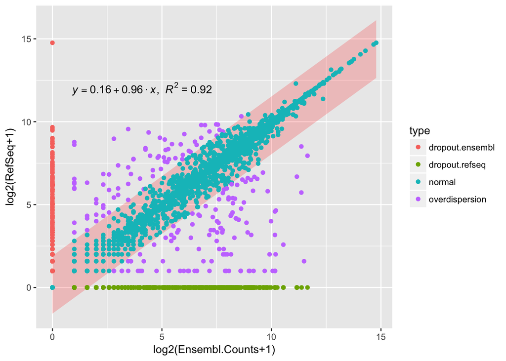

```r
##this function just label model in plot
equation = function(x) {
  lm_coef <- list(a = round(coef(x)[1], digits = 2),
                  b = round(coef(x)[2], digits = 2),
                  r2 = round(summary(x)$r.squared, digits = 2));
  lm_eq <- substitute(italic(y) == a + b %.% italic(x)*","~~italic(R)^2~"="~r2,lm_coef)
  as.character(as.expression(lm_eq));
}
##label with color
type<-rep('normal',nrow(ensembl.refseq))
type[ensembl.refseq$Ensembl.Counts==0 & ensembl.refseq$RefSeq.Counts>0]<-'dropout.ensembl'
type[ensembl.refseq$Ensembl.Counts>0 & ensembl.refseq$RefSeq.Counts==0]<-'dropout.refseq'
type[(ensembl.refseq$RefSeq.Counts > conf_interval[,3]|ensembl.refseq$RefSeq.Counts<conf_interval[,2])&(ensembl.refseq$Ensembl.Counts>0 & ensembl.refseq$RefSeq.Counts>0)]<-'overdispersion'
ensembl.refseq$type<-type
## label prefiction model in plot
eq <- substitute(italic(y) == a + b %.% italic(x)*","~~italic(r)^2~"="~r2, list(a = format(coef(fit)[1], digits = 2), b = format(coef(fit)[2], digits = 2), r2 = format(summary(fit)$r.squared, digits = 3)))
## scatter plot
p1 <- ggplot(ensembl.refseq,aes(x=Ensembl.Counts,y=RefSeq.Counts),color="grey")
p1<-p1+geom_ribbon(aes(ymin=conf_interval[,2],ymax=conf_interval[,3]),alpha=0.2,fill="red")
p1<-p1+geom_point(data=ensembl.refseq,aes(x=Ensembl.Counts,y=RefSeq.Counts,color=type))
p1<-p1+annotate("text", x = 4.1, y = 12, label = equation(fit), parse = TRUE)
p1<-p1+xlab("log2(Ensembl.Counts+1)")+ylab("log2(RefSeq+1)")
p1
```

- Count drop-out genes in `Ensembl` compared to `RefSeq`

```r
dropout.ensembl<-subset(ensembl.refseq,Ensembl.Counts==0 & RefSeq.Counts>0)
dim(dropout.ensembl)
```

```
## [1] 325   6
```

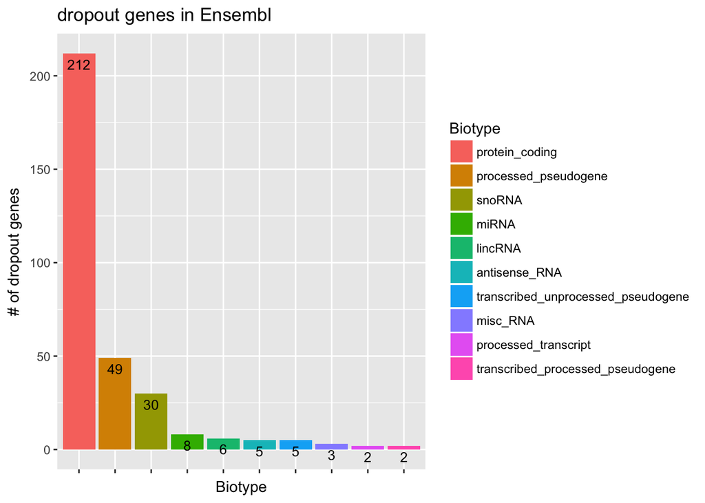

```r
## barplot
x<-data.frame(sort(table(dropout.ensembl$Ensembl.type),decreasing=T)[1:10])
colnames(x)<-c('Biotype','Counts')
ggplot(data.frame(x),aes(x=Biotype,y=Counts))+geom_bar(aes(fill = Biotype), position = "dodge", stat="identity")+xlab('Biotype')+ylab("# of dropout genes")+geom_text(aes(label=Counts), vjust=1.6, color="black", size=3.5) +theme(axis.text.x=element_blank())+ggtitle('dropout genes in Ensembl')
```

- We want to know whether the `dropout` genes in Ensembl have any biological functional meaning. We overlap `dropout` genes with MSigDB `C2_curated` geneset, `C2_curated` geneset contain most `KEGG` pathway. two way to calculate the geneset overlapping, Fisher-exact test and hyper-geometry test. We use both tests.

```r
library(GeneOverlap)
library(MSigDB)
## create function to do overlapping test
gsOverlap<-function(gs_cureated,gs){
  ##msigdb_c2<-MSigDB[["C2_CURATED"]]
  pvals<-c()
  for(i in names(gs_curated)){
    go.obj <- newGeneOverlap(gs_curated[[i]], gs, genome.size=60000)
    ##fisher exact
    go.obj <- testGeneOverlap(go.obj)
    overlap<-length(getIntersection(go.obj))
    PopSize<-60000
    f.pval<-getPval(go.obj)
    list1<-length(gs)
    list2<-length(gs_curated[[i]])
    ##hyperGT
    if(overlap>1){
     h.pval<-phyper(overlap-1,list1,PopSize-list1,list2,lower.tail = FALSE, log.p = FALSE)
  }else{
    h.pval<-1
    }
    pvals<-rbind(pvals,c(i,overlap,list1,list2,f.pval,h.pval))
  }
  colnames(pvals)<-c('gsName','overlap','dropout.gs.length','msigdb.gs.length','fisher','hyper')
  pvals<-data.frame(pvals)
  pvals$fisher.adj<-p.adjust(pvals$fisher)
  pvals$hyper.adj<-p.adjust(pvals$hyper)
  return(pvals)
}

## do test : ensembl
gs_curated<-MSigDB[["C2_CURATED"]]
gs<-dropout.ensembl$geneName
res<-gsOverlap(gs_curated,gs)
head(res)
```

```
##                                          gsName overlap dropout.gs.length
## 1               KEGG_GLYCOLYSIS_GLUCONEOGENESIS       0               325
## 2                  KEGG_CITRATE_CYCLE_TCA_CYCLE       1               325
## 3                KEGG_PENTOSE_PHOSPHATE_PATHWAY       0               325
## 4 KEGG_PENTOSE_AND_GLUCURONATE_INTERCONVERSIONS       0               325
## 5          KEGG_FRUCTOSE_AND_MANNOSE_METABOLISM       1               325
## 6                     KEGG_GALACTOSE_METABOLISM       0               325
##   msigdb.gs.length            fisher hyper fisher.adj hyper.adj
## 1               62                 1     1          1         1
## 2               32  0.14731970863215     1          1         1
## 3               27                 1     1          1         1
## 4               28                 1     1          1         1
## 5               34 0.155773200040791     1          1         1
## 6               26                 1     1          1         1
```

```r
sum(res$fisher.adj<0.05)
```

```
## [1] 0
```

```r
sum(res$hyper.adj<0.05)
```

```
## [1] 0
```

```r
## hypherGtest
```

So there is no significant enrichment with any genesets in C2. And repeat this analysis with the `dropout` genes in RefSeq

```r
dropout.refseq<-subset(ensembl.refseq,Ensembl.Counts>0 & RefSeq.Counts==0)
dim(dropout.refseq)
```

```
## [1] 954   6
```

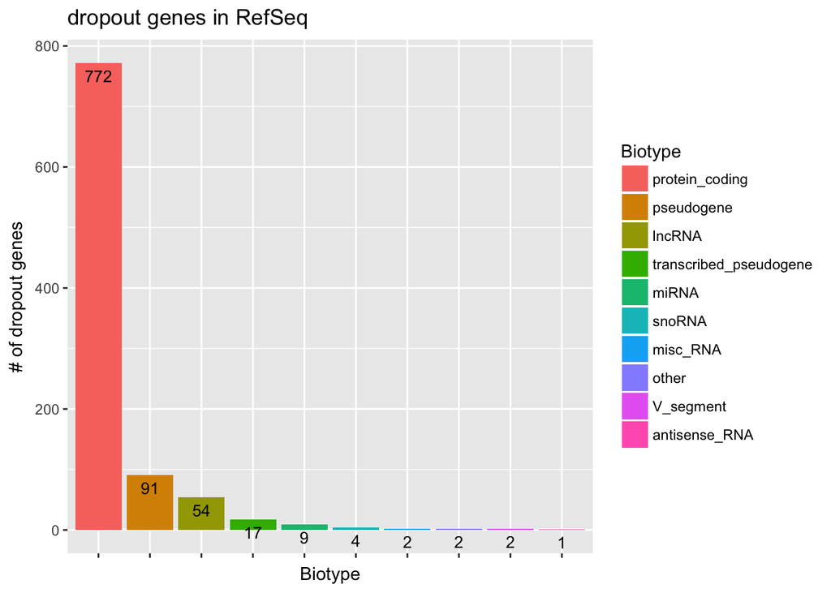

```r
##barplot(sort(table(dropout.refseq$RefSeq.type),decreasing=T)[1:10],main="Dropout genes: RefSeq")
x<-data.frame(sort(table(dropout.refseq$RefSeq.type),decreasing=T)[1:10])
colnames(x)<-c('Biotype','Counts')
ggplot(data.frame(x),aes(x=Biotype,y=Counts))+geom_bar(aes(fill = Biotype), position = "dodge", stat="identity")+xlab('Biotype')+ylab("# of dropout genes")+geom_text(aes(label=Counts), vjust=1.6, color="black", size=3.5) +theme(axis.text.x=element_blank())+ggtitle('dropout genes in RefSeq')
```

RefSeq’s `dropout` genes have any functional meaning?

```r
gs<-dropout.refseq$geneName
res<-gsOverlap(gs_curated,gs)
head(res)
```

```
##                                          gsName overlap dropout.gs.length
## 1               KEGG_GLYCOLYSIS_GLUCONEOGENESIS       1               954
## 2                  KEGG_CITRATE_CYCLE_TCA_CYCLE       0               954
## 3                KEGG_PENTOSE_PHOSPHATE_PATHWAY       0               954
## 4 KEGG_PENTOSE_AND_GLUCURONATE_INTERCONVERSIONS       0               954
## 5          KEGG_FRUCTOSE_AND_MANNOSE_METABOLISM       0               954
## 6                     KEGG_GALACTOSE_METABOLISM       0               954
##   msigdb.gs.length            fisher hyper fisher.adj hyper.adj
## 1               62 0.431631750435291     1          1         1
## 2               32                 1     1          1         1
## 3               27                 1     1          1         1
## 4               28                 1     1          1         1
## 5               34                 1     1          1         1
## 6               26                 1     1          1         1
```

```r
sum(res$fisher.adj<0.05)
```

```
## [1] 0
```

```r
sum(res$hyper.adj<0.05)
```

```
## [1] 0
```

## `GencodeV27Basic` vs `refSeq`

- We repeat the analysis to compare `GencodeV27Basic` with `RefSeq`.

```r
gencode.refseq<-merge(c2,c4,by=c('geneName'),all=F, all.x=F,all.y=F)
dim(gencode.refseq)
```

```
## [1] 57943     5
```

- Regression model

```r
subdata<-subset(gencode.refseq,GencodeBasic.Counts>0 & RefSeq.Counts >0)
fit<-lm(RefSeq.Counts~GencodeBasic.Counts, data=subdata)
summary(fit)
```

```
##
## Call:
## lm(formula = RefSeq.Counts ~ GencodeBasic.Counts, data = subdata)
##
## Residuals:
##     Min      1Q  Median      3Q     Max
## -9.4115 -0.1340 -0.0216  0.0356  9.3393
##
## Coefficients:
##                     Estimate Std. Error t value Pr(>|t|)
## (Intercept)         0.214134   0.021139   10.13   <2e-16 ***
## GencodeBasic.Counts 0.973297   0.003087  315.27   <2e-16 ***
## ---
## Signif. codes:  0 '***' 0.001 '**' 0.01 '*' 0.05 '.' 0.1 ' ' 1
##
## Residual standard error: 0.6724 on 4939 degrees of freedom
## Multiple R-squared:  0.9527, Adjusted R-squared:  0.9527
## F-statistic: 9.94e+04 on 1 and 4939 DF,  p-value: < 2.2e-16
```

- estimate 95% prediction interval. For a data point

```r
pred<-predict(fit,data=gencode.refseq)
conf_interval_3 <- predict(fit, newdata=data.frame(GencodeBasic.Counts=100), interval="prediction",level = 0.95)
conf_interval_3
```

```
##        fit      lwr      upr
## 1 97.54379 96.10816 98.97943
```

95% prediction intervals for regression line

```r
conf_interval <- predict(fit, newdata=gencode.refseq, interval="prediction",level = 0.95)
```

- visualize results in scatterplot

```r
##label with color
type<-rep('normal',nrow(gencode.refseq))
type[gencode.refseq$GencodeBasic.Counts==0 & gencode.refseq$RefSeq.Counts>0]<-'dropout.gencode'
type[gencode.refseq$GencodeBasic.Counts>0 & gencode.refseq$RefSeq.Counts==0]<-'dropout.refseq'
type[(gencode.refseq$RefSeq.Counts > conf_interval[,3] | gencode.refseq$RefSeq.Counts<conf_interval[,2])&(gencode.refseq$GencodeBasic.Counts>0 & gencode.refseq$RefSeq.Counts>0)]<-'overdispersion'
gencode.refseq$type<-type
table(gencode.refseq$type)
```

```
##
## dropout.gencode  dropout.refseq          normal  overdispersion
##             483             367           56918             175
```

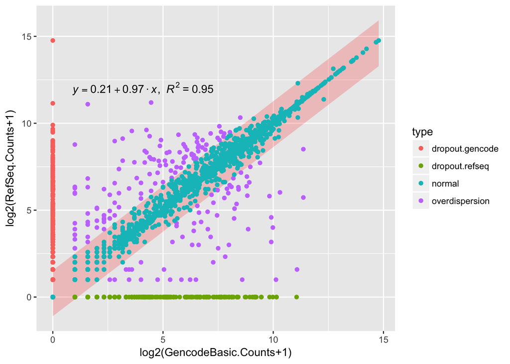

```r
## label prefiction model in plot
eq <- substitute(italic(y) == a + b %.% italic(x)*","~~italic(r)^2~"="~r2, list(a = format(coef(fit)[1], digits = 2), b = format(coef(fit)[2], digits = 2), r2 = format(summary(fit)$r.squared, digits = 3)))
## scatter plot
p1 <- ggplot(gencode.refseq,aes(x=GencodeBasic.Counts,y=RefSeq.Counts),color="grey")
p1<-p1+geom_ribbon(aes(ymin=conf_interval[,2],ymax=conf_interval[,3]),alpha=0.2,fill="red")
p1<-p1+geom_point(data=gencode.refseq,aes(x=GencodeBasic.Counts,y=RefSeq.Counts,color=type))
p1<-p1+annotate("text", x = 4.1, y = 12, label = equation(fit), parse = TRUE)
p1<-p1+xlab("log2(GencodeBasic.Counts+1)")+ylab("log2(RefSeq.Counts+1)")
p1
```

- Count drop-out genes in `GencodeV27 basic` compared to `RefSeq`

```r
dropout.gencode<-subset(gencode.refseq,GencodeBasic.Counts==0 & RefSeq.Counts>0)
dim(dropout.gencode)
```

```
## [1] 483   6
```

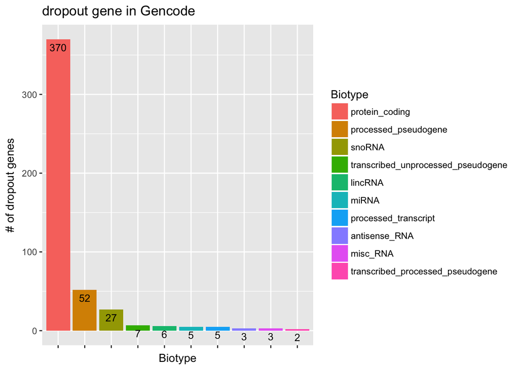

```r
#barplot(sort(table(dropout.gencode$Gencode.type),decreasing=T)[1:10],main="Dropout genes: GencodeBasic")
x<-data.frame(sort(table(dropout.gencode$Gencode.type),decreasing=T)[1:10])
colnames(x)<-c('Biotype','Counts')
ggplot(data.frame(x),aes(x=Biotype,y=Counts))+geom_bar(aes(fill = Biotype), position = "dodge", stat="identity")+xlab('Biotype')+ylab("# of dropout genes")+geom_text(aes(label=Counts), vjust=1.6, color="black", size=3.5) +theme(axis.text.x=element_blank())+ggtitle('dropout gene in Gencode')
```

whether `dropout` genes have any functional meaning?

```r
gs<-dropout.gencode$geneName
gs_curated<-MSigDB[["C2_CURATED"]]
res<-gsOverlap(gs_curated,gs)
head(res)
```

```
##                                          gsName overlap dropout.gs.length
## 1               KEGG_GLYCOLYSIS_GLUCONEOGENESIS       0               483
## 2                  KEGG_CITRATE_CYCLE_TCA_CYCLE       1               483
## 3                KEGG_PENTOSE_PHOSPHATE_PATHWAY       0               483
## 4 KEGG_PENTOSE_AND_GLUCURONATE_INTERCONVERSIONS       0               483
## 5          KEGG_FRUCTOSE_AND_MANNOSE_METABOLISM       1               483
## 6                     KEGG_GALACTOSE_METABOLISM       0               483
##   msigdb.gs.length            fisher hyper fisher.adj hyper.adj
## 1               62                 1     1          1         1
## 2               32 0.186206270465911     1          1         1
## 3               27                 1     1          1         1
## 4               28                 1     1          1         1
## 5               34 0.196622073569762     1          1         1
## 6               26                 1     1          1         1
```

```r
sum(res$fisher.adj<0.05)
```

```
## [1] 0
```

```r
sum(res$hyper.adj<0.05)
```

```
## [1] 0
```

Then the drop-out genes in `RefSeq` compared to `GencodeV27 Basic`

```r
dropout.refseq<-subset(gencode.refseq,GencodeBasic.Counts>0 & RefSeq.Counts==0)
dim(dropout.refseq)
```

```
## [1] 367   6
```

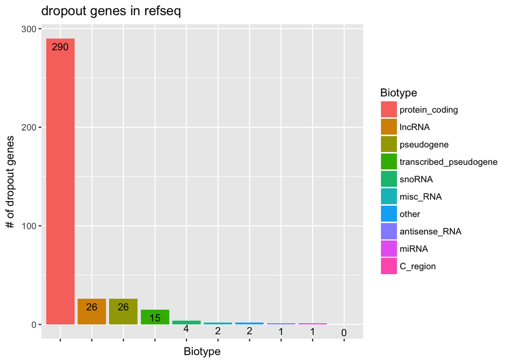

```r
##barplot(sort(table(dropout.refseq$RefSeq.type),decreasing=T)[1:10],main="Dropout genes: RefSeq")
x<-data.frame(sort(table(dropout.refseq$RefSeq.type),decreasing=T)[1:10])
colnames(x)<-c('Biotype','Counts')
ggplot(data.frame(x),aes(x=Biotype,y=Counts))+geom_bar(aes(fill = Biotype), position = "dodge", stat="identity")+xlab('Biotype')+ylab("# of dropout genes")+geom_text(aes(label=Counts), vjust=1.6, color="black", size=3.5) +theme(axis.text.x=element_blank())+ggtitle('dropout genes in refseq')
```

Whether `dropout` genes have functional meaning?

```r
gs<-dropout.refseq$geneName
gs_curated<-MSigDB[["C2_CURATED"]]
res<-gsOverlap(gs_curated,gs)
head(res)
```

```
##                                          gsName overlap dropout.gs.length
## 1               KEGG_GLYCOLYSIS_GLUCONEOGENESIS       0               367
## 2                  KEGG_CITRATE_CYCLE_TCA_CYCLE       0               367
## 3                KEGG_PENTOSE_PHOSPHATE_PATHWAY       0               367
## 4 KEGG_PENTOSE_AND_GLUCURONATE_INTERCONVERSIONS       0               367
## 5          KEGG_FRUCTOSE_AND_MANNOSE_METABOLISM       0               367
## 6                     KEGG_GALACTOSE_METABOLISM       0               367
##   msigdb.gs.length fisher hyper fisher.adj hyper.adj
## 1               62      1     1          1         1
## 2               32      1     1          1         1
## 3               27      1     1          1         1
## 4               28      1     1          1         1
## 5               34      1     1          1         1
## 6               26      1     1          1         1
```

```r
sum(res$fisher.adj<0.05)
```

```
## [1] 0
```

```r
sum(res$hyper.adj<0.05)
```

```
## [1] 0
```

# 4-ways overlapping

- Next, we evaluate the 4-way overlapping on `dectected genes` between reference bundles.

```r
library('VennDiagram')
```

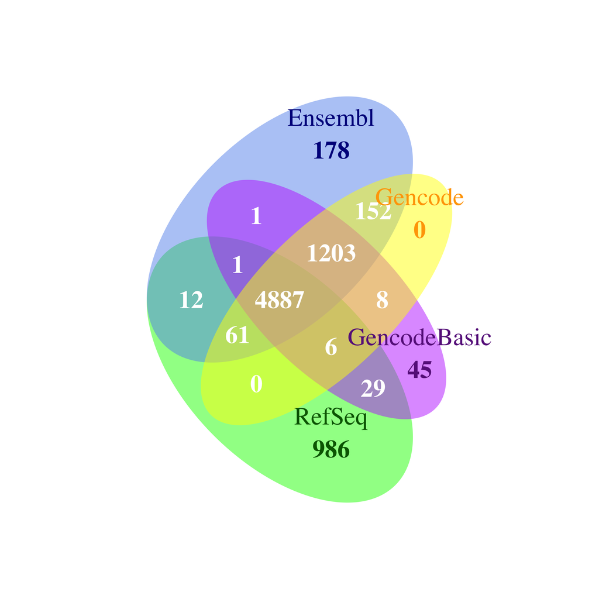

```r
g1<-c1[c1$Ensembl.Counts>0,1]
g2<-c2[c2$RefSeq.Counts>0,1]
g3<-c3[c3$GencodeComp.Counts>0,1]
g4<-c4[c4$GencodeBasic.Counts>0,1]
venn.plot<-venn.diagram(x = list('Ensembl'=g1,'RefSeq'=g2,'Gencode'=g3,'GencodeBasic'=g4), imagetype='png',filename = "Venn.png",
col = "transparent", fill = c("cornflowerblue","green","yellow","darkorchid1"),
label.col = c("orange", "white", "darkorchid4", "white", "white",
"white",    "white", "white", "darkblue", "white", "white", "white", "white",
"darkgreen", "white"),alpha = 0.50,cex = 1.5, fontfamily = "serif", fontface = "bold",
cat.col = c("darkblue", "darkgreen", "orange", "darkorchid4"), cat.cex = 1.5,
cat.pos = 0, cat.dist = 0.07, cat.fontfamily = "serif", rotation.degree = 270,
margin = 0.2)
```

- we evaluate the 4-way overlapping on `high coverage genes (>5X)` between reference bundles.

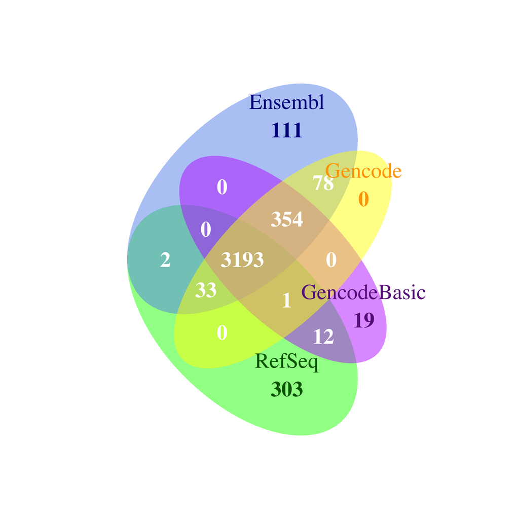

high covered genes

```r
g1<-c1[c1$Ensembl.Counts>5,1]
g2<-c2[c2$RefSeq.Counts>5,1]
g3<-c3[c3$GencodeComp.Counts>5,1]
g4<-c4[c4$GencodeBasic.Counts>5,1]
venn.plot<-venn.diagram(x = list('Ensembl'=g1,'RefSeq'=g2,'Gencode'=g3,'GencodeBasic'=g4), imagetype='png',filename = "Venn_good_genes.png",
col = "transparent", fill = c("cornflowerblue","green","yellow","darkorchid1"),
label.col = c("orange", "white", "darkorchid4", "white", "white",
"white",    "white", "white", "darkblue", "white", "white", "white", "white",
"darkgreen", "white"),alpha = 0.50,cex = 1.5, fontfamily = "serif", fontface = "bold",
cat.col = c("darkblue", "darkgreen", "orange", "darkorchid4"), cat.cex = 1.5,
cat.pos = 0, cat.dist = 0.07, cat.fontfamily = "serif", rotation.degree = 270,
margin = 0.2)
```